# HW2_solutions

**Dragos Ailoae**

Applied Statistics and Econometrics I

2021-10-12

## Homework 2 - Suggested Solutions

### Problem 1:

For the regression model $Y =\beta_{0}+\beta_{1}X+\varepsilon$,

a. Show that the least squares normal equations imply that $$ \sum_{i=1}^{N} e_{i}=0 \text { and } \sum_{i=1}^{N} x_{i} e_{i}=0 $$

Remember, the OLS optimization problem is to find parameters $\hat \beta_0, \hat \beta_1$ in order to minimize the sum of deviations in the vertical distance between our observed $y_i$ and the predicted $\hat y_i = \hat\beta_0+\hat\beta_1 x_i$. We call this difference the residual $e_i = y_i-\hat y_i$ and we measure the deviation as the square of this difference in order to make it a positive value (absolute values are more cumbersome in calculus).

The problem is defined as: $$ \min _{\hat{\beta}_{0}, \hat{\beta}_{1}} Q = \sum_{i=1}^{N}\left(y_{i}-\hat{\beta}_{0}-\hat{\beta}_{1} x_{i}\right)^{2} $$

Where $Q$ is also known as the **sum of squared residuals** (SSR) or **residuals sum of squares**(RSS).

To solve the minimization problem, we need to take the partial derivatives with respect to our parameters and set them equal to 0. This gives us:

\begin{equation} \frac{\partial Q}{\partial \hat{\beta}_{0}}=\sum_{i=1}^{N}-2\left(y_{i}-\hat{\beta}_{0}-\hat{\beta}_{1} x_{i}\right)=0 \end{equation}\begin{equation} \frac{\partial Q}{\partial \hat{\beta}_{1}}=\sum_{i=1}^{N}-2 x_{i}\left(y_{i}-\hat{\beta}_{0}-\hat{\beta}_{1} x_{i}\right)=0 \end{equation}

Equations (1) and (2) are called the **normal equations**, they are basically the system of equations we solve to obtain our parameters $\hat \beta_0,\hat \beta_1$.

So problem 1a is basically asking: with the normal equations as given, prove these two corollaries $\sum_{i=1}^{N} e_{i}=0$ and $\sum_{i=1}^{N} x_{i} e_{i}=0$.

To prove $\sum_{i=1}^{N} e_{i}=0$ we note that since $e_i = y_i-\hat y_i$ and $\hat y_i = \hat\beta_0+\hat\beta_1 x_i$ we can write \begin{equation} e_i = y_i-\hat\beta_0-\hat\beta_1 x_i \end{equation}

so we essentially need to prove that \begin{equation} \sum_{i=1}^{N} e_{i}= \sum_{i=1}^{N} \left(y_i-\hat\beta_0-\hat\beta_1 x_i \right) = 0 \end{equation}

But this is just normal equation (1) i.e. dividing both sides of equation (1) by $-2$ gives us: \begin{equation} \sum_{i=1}^{N} \left(y_{i}-\hat{\beta}_{0}-\hat{\beta}_{1} x_{i}\right) =0 \end{equation}

Since (1) is true then (4) must also be true, QED.

Similarly, to prove $\sum_{i=1}^{N} x_{i} e_{i}=0$ we use (3) to redefine the expression as:

\begin{equation} \sum_{i=1}^{N} x_{i} e_{i}=\sum_{i=1}^{N}x_{i}\left(y_{i}-\hat{\beta}_{0}-\hat{\beta}_{1} x_{i}\right)=0 \end{equation}

Then we note that dividing both sides of normal equation (2) by $-2$ gives us: \begin{equation} \sum_{i=1}^{N}x_{i}\left(y_{i}-\hat{\beta}_{0}-\hat{\beta}_{1} x_{i}\right)=0 \end{equation}

Since (2) is true then (6) must be true, QED.

b. Show that the solution for the constant term is: $$ \hat\beta_0 = \bar Y - \hat\beta_1 \bar X $$

Let's start with the simplified version of normal equation 1 which we saw above as equation (5). It follows that \begin{align*} \sum_{i=1}^{N}\hat\beta_0 &= \sum_{i=1}^{N}\left(y_i - \hat\beta_1 x_i \right) \\ N \hat\beta_0 &= \sum_{i=1}^{N}\left(y_i - \hat\beta_1 x_i \right) \\ \hat\beta_0 &= \frac{1}{N} \sum_{i=1}^{N} y_i - \frac{1}{N} \sum_{i=1}^{N} \hat\beta_1 x_i \\ \hat\beta_0 &= \frac{1}{N} \sum_{i=1}^{N} y_i - \hat\beta_1\frac{1}{N} \sum_{i=1}^{N}x_i \\ \hat\beta_0 &= \bar Y - \hat\beta_1 \bar X \end{align*}

### Problem 2:

Show that the assumption $E(\varepsilon \mid x) = 0$ implies that $\operatorname{Cov}(x, \varepsilon)=0$.

Per [Greene Appendix](http://pages.stern.nyu.edu/~wgreene/Text/Greene-EA-7&8ed-Appendices.pdf):

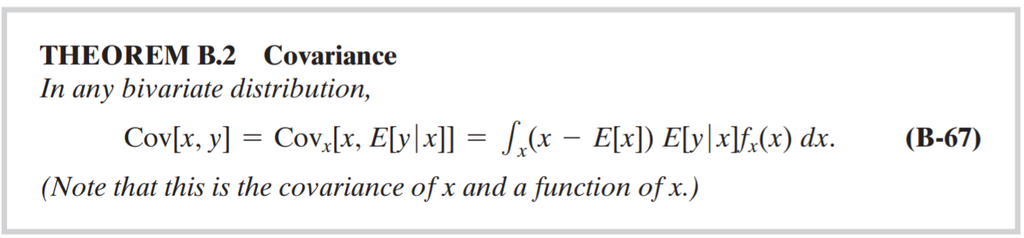

In our case $$ \operatorname{Cov}[x, \varepsilon]=\operatorname{Cov}_{x}[x, E[\epsilon \mid x]]=\int_{x}(x-E[x]) E[\varepsilon \mid x] f_{x}(x) d x $$

Since $E[\varepsilon \mid x] = 0$ it follows that $Cov[x,\varepsilon]=0$.

Alternately, we note that \begin{equation} Cov[x,\varepsilon]=E[x \varepsilon]-E[x]E[\varepsilon] = E[x \varepsilon]-E[x] \times 0 = E[x \varepsilon] \end{equation}

By the law of iterated expectations (see [Greene Appendix](http://pages.stern.nyu.edu/~wgreene/Text/Greene-EA-7&8ed-Appendices.pdf) B-66): \begin{equation} E[x \varepsilon] = E[E[x\varepsilon \mid x]] = E[x E[\varepsilon \mid x]] = E[x\times0]=0 \end{equation}

It follows then that $Cov[x,\varepsilon]=0$

### Problem 3:

Suppose we have the following data on GPA and Income.

| GPA | Income |
| --- | --- |
| (Grade Point Average) | (Income of parents in $1000) |
| 4.0 | 21.0 |
| 3.0 | 15.0 |
| 3.5 | 15.0 |
| 2.0 | 9.0 |
| 3.0 | 12.0 |
| 3.5 | 18.0 |
| 2.5 | 6.0 |
| 2.5 | 12.0 |

Calculate the regression of income on GPA and compare it with the regression of GPA on income. Why are the two different?

### Method 1: Summations

$$ \hat\beta_0 = \frac{1}{N} \sum_{i=1}^{N} y_i - \hat\beta_1\frac{1}{N} \sum_{i=1}^{N}x_i =\bar y - \hat\beta_1 \bar x $$$$ \hat{\beta}_{1} =\frac{\frac{1}{N} \sum_{i=1}^{N}\left(x_{i}-\bar{x}\right)\left(y_{i}-\bar{y}\right)}{\frac{1}{N} \sum_{i=1}^{N}\left(x_{i}-\bar{x}\right)^{2}}=\frac{\operatorname{Cov}(x, y)}{\operatorname{Var}(x)} $$

**Model 1: Income ~ GPA**

We'll define the population model as $Income =\beta_{0}+\beta_{1}GPA+\varepsilon$

```r
GPA <- c(4.0,3.0,3.5,2.0,3.0,3.5,2.5,2.5)
Income <- c(21.0, 15.0, 15.0, 9.0, 12.0, 18.0, 6.0, 12.0)
m1.beta.hat.1 <- cov(GPA,Income) / var(GPA)
m1.beta.hat.1
```

6.5

```r
m1.beta.hat.0 <-mean(Income) - m1.beta.hat.1 * mean(GPA)
m1.beta.hat.0
```

-6

So for model 1 we have $\hat \beta_0$ = -6 and $\hat \beta_1$ = 6.5. Let's look at model 2:

**Model 2: GPA ~ Income**

We'll define the population model as $GPA =\beta_{0}+\beta_{1}Income+\varepsilon$

```r
m2.beta.hat.1 <- cov(GPA,Income) / var(Income)
round(m2.beta.hat.1,3)
```

0.12

```r
m2.beta.hat.0 <-mean(GPA) - m2.beta.hat.1 * mean(Income)
m2.beta.hat.0
```

1.375

**Conclusion: The reason for the difference is that, while both calculations for $\hat \beta_1$ are based on the covariance between the same two variables, in model 1 we scale the covariance by the variance of GPA while in model 2 we scale it by the variance of Income. Different y-intercepts, $\hat \beta_0$'s, are a consequence of these different slopes**

### Method 2: Matrices

The OLS estimator in matrix form is $\hat \beta = (X'X)^{-1}X'y$ so for model 1 we have:

**Model 1: Income ~ GPA**

$$ \hat \beta =\left.\left(\begin{array}{l} \hat{\beta}_{0} \\ \hat{\beta}_{1} \end{array}\right)=\left(\left[\begin{array}{cccccccc} 1 & 1 & 1 & 1 & 1 & 1 & 1 & 1 \\ 4.0 & 3.0 & 3.5 & 2.0 & 3.0 & 3.5 & 2.5 & 2.5 \end{array}\right] \times\left[\begin{array}{ccccccc} 1 & 4.0 \\ 1 & 3.0 \\ 1 & 3.5 \\ 1 & 2.0 \\ 1 & 3.0 \\ 1 & 3.5 \\ 1 & 2.5 \\ 1 & 2.5 \end{array}\right]\right) ^{-1} \times\left[\begin{array}{cccccccc} 1 & 1 & 1 & 1 & 1 & 1 & 1 & 1 \\ 4.0 & 3.0 & 3.5 & 2.0 & 3.0 & 3.5 & 2.5 & 2.5 \end{array}\right]\left[\begin{array}{c} 21 \\ 15 \\ 15 \\ 9 \\ 12 \\ 18 \\ 6 \\ 12 \end{array}\right]\right) $$

We'll first need to add the intercept column of 1s (also known as the 'bias') to our X (or data) matrix.

```r
intercept <- rep(1, length(GPA))
intercept
```

1. 1

2. 1

3. 1

4. 1

5. 1

6. 1

7. 1

8. 1

Next we append it to our independent variable vector:

```r
X <- cbind(intercept, GPA)
X
```

A matrix: 8 × 2 of type dbl

| intercept | GPA |
| --- | --- |
| 1 | 4.0 |
| 1 | 3.0 |
| 1 | 3.5 |
| 1 | 2.0 |
| 1 | 3.0 |
| 1 | 3.5 |
| 1 | 2.5 |
| 1 | 2.5 |

Setting our dependent variable y as Income we can then calculate our betas:

```r
y <- Income
m1.betas <- solve(t(X) %*% X) %*% t(X) %*% y
m1.betas
```

A matrix: 2 × 1 of type dbl

| intercept | -6.0 |
| --- | --- |
| GPA | 6.5 |

To print separately:

```r
paste0("Model 1: Income ~ GPA")
paste0("Intercept is ",m1.betas[1])
paste0("GPA coefficient is ",round(m1.betas[2],3))
```

'Model 1: Income ~ GPA'

'Intercept is -6'

'GPA coefficient is 6.5'

**Model 2: GPA ~ Income**

```r
X <- cbind(intercept, Income)
y <- GPA
m2.betas <- solve(t(X) %*% X) %*% t(X) %*% y
round(m2.betas,3)
```

A matrix: 2 × 1 of type dbl

| intercept | 1.375 |
| --- | --- |
| Income | 0.120 |

```r
paste0("Model 2: GPA ~ Income")
paste0("Intercept is ",m2.betas[1])
paste0("Income coefficient is ",round(m2.betas[2],3))
```

'Model 2: GPA ~ Income'

'Intercept is 1.375'

'Income coefficient is 0.12'

### Problem 4:

What happens to the least squares slope and intercept estimates when all observations on the independent variable are identical? Show how you arrived at your answer.

Note that $$ \hat{\beta}_{1} =\frac{\frac{1}{N} \sum_{i=1}^{N}\left(x_{i}-\bar{x}\right)\left(y_{i}-\bar{y}\right)}{\frac{1}{N} \sum_{i=1}^{N}\left(x_{i}-\bar{x}\right)^{2}}=\frac{\operatorname{Cov}(x, y)}{\operatorname{Var}(x)} $$

Since all x's are the same that means $x_i=\bar x$ the denominator is 0 (no variance) meaning we cannot estimate our coefficients. Or, in matrix terms, $\hat \beta = (X'X)^{-1}X'y$ but the $(X'X)$ matrix is singular therefore non-invertible.

To convince ourselves let's try an example:

```r
X <- matrix(c(1, 3,
              1, 3,
              1, 3),byrow=T, nrow=3)
X
```

A matrix: 3 × 2 of type dbl

| 1 | 3 |
| --- | --- |
| 1 | 3 |
| 1 | 3 |

```r
XprimeX <- t(X) %*% X
XprimeX
```

A matrix: 2 × 2 of type dbl

| 3 | 9 |
| --- | --- |
| 9 | 27 |

```r
solve(XprimeX)
```

```
Error in solve.default(XprimeX): Lapack routine dgesv: system is exactly singular: U[2,2] = 0
Traceback:

1. solve(XprimeX)
2. solve.default(XprimeX)
```

Inverting fails because "system is exactly singular"

Also note that the columns of X are exactly collinear (more of this later in the course) so the X matrix is not full rank.

```r
options(warn=-1) # Suppress warnings
qui <- suppressPackageStartupMessages # quiet! - suppress library load messages
qui(if(!require(Matrix)){install.packages('Matrix')}) # for 'rankMatrix' function

paste('Number of Columns: ',dim(X)[2])
paste('Matrix Rank: ',rankMatrix(X))
```

'Number of Columns: 2'

'Matrix Rank: 1'

### Problem 5:

Suppose that the coefficient in the regression of income on GPA in problem 3 was -1.7. How would you interpret it?

A one point increase in GPA is associated with a $1700 decrease in parents' income.

### Problem 6:

Assume that least squares estimates are obtained for the relationship $Y =\beta_{0}+\beta_{1}X+\varepsilon$. After the work is completed, it is decided to multiply the units of the $X$ variable by a factor of 10 . What will happen to the least squares slope and intercept?

Remember, $$ \hat\beta_0 = \frac{1}{N} \sum_{i=1}^{N} y_i - \hat\beta_1\frac{1}{N} \sum_{i=1}^{N}x_i $$

$$ \hat{\beta}_{1} =\frac{\frac{1}{N} \sum_{i=1}^{N}\left(x_{i}-\bar{x}\right)\left(y_{i}-\bar{y}\right)}{\frac{1}{N} \sum_{i=1}^{N}\left(x_{i}-\bar{x}\right)^{2}} $$

Multiplying X by 10 results in the following change to the slope coefficient: $$ \hat{\beta}^{*}_{1} =\frac{\frac{1}{N} \sum_{i=1}^{N}\left(10 x_{i}-10\bar{x}\right)\left(y_{i}-\bar{y}\right)}{\frac{1}{N} \sum_{i=1}^{N}\left(10x_{i}-10\bar{x}\right)^{2}} = \frac{10\frac{1}{N} \sum_{i=1}^{N}\left(x_{i}-\bar{x}\right)\left(y_{i}-\bar{y}\right)}{100\frac{1}{N} \sum_{i=1}^{N}\left(x_{i}-\bar{x}\right)^{2}} = \frac{1}{10} \hat{\beta}_{1} $$

While for the intercept:

\begin{align*} \hat\beta^{*}_0 &= \frac{1}{N} \sum_{i=1}^{N} y_i - \hat\beta^{*}_1\frac{1}{N} \sum_{i=1}^{N}10x_i \\ &= \frac{1}{N} \sum_{i=1}^{N} y_i - 10\hat\beta^{*}_1\frac{1}{N} \sum_{i=1}^{N}x_i \\ &= \frac{1}{N} \sum_{i=1}^{N} y_i - 10\frac{1}{10} \hat{\beta}_{1}\frac{1}{N} \sum_{i=1}^{N}x_i \\ &=\frac{1}{N} \sum_{i=1}^{N} y_i - \hat\beta_1\frac{1}{N} \sum_{i=1}^{N}x_i \\ &= \hat\beta_0 \end{align*}

Conclusion: If we only scale X the slope coefficient gets rescaled (inverse proportionally) while the intercept stays the same.

What happens to the slope and intercept if both the X and Y variables are multiplied by a factor of 10?

In this case:

$$ \hat{\beta}^{*}_{1} =\frac{\frac{1}{N} \sum_{i=1}^{N}\left(10 x_{i}-10\bar{x}\right)\left(10y_{i}-10\bar{y}\right)}{\frac{1}{N} \sum_{i=1}^{N}\left(10x_{i}-10\bar{x}\right)^{2}} = \frac{100\frac{1}{N} \sum_{i=1}^{N}\left(x_{i}-\bar{x}\right)\left(y_{i}-\bar{y}\right)}{100\frac{1}{N} \sum_{i=1}^{N}\left(x_{i}-\bar{x}\right)^{2}} = \hat{\beta}_{1} $$

While for the intercept:

\begin{align*} \hat\beta^{*}_0 &= \frac{1}{N} \sum_{i=1}^{N} 10 y_i - \hat\beta^{*}_1\frac{1}{N} \sum_{i=1}^{N}10x_i \\ &= 10\frac{1}{N} \sum_{i=1}^{N} y_i - 10\hat\beta_1\frac{1}{N} \sum_{i=1}^{N}x_i \\ &=10 \left(\frac{1}{N} \sum_{i=1}^{N} y_i - \hat\beta_1\frac{1}{N} \sum_{i=1}^{N}x_i \right) \\ &=10 \hat\beta_0 \end{align*}

Conclusion: If we scale both X an Y by the same factor the slope coefficient does not change but the intercept gets proportionally rescaled.